# EX03: ECG signal during atrial fibrilation

The objective of this exercise is to study the signal of ECG during atrial  
fibrilation (AF). The signal analysed contains different type of AF with  
stable repolarisation loops and random AF.

```python
import numpy as np
import pylab as py
py.ion()
py.close('all')
import scipy.signal as sp
```

The first signal is an ECG with atrial fibrilation.  
Q: What are the differences of this ECG with a normal ECG?

Looking at the plotted trace, the main differences between a normal ECG and one with atrial fibrillation are:

- **Absence of P waves**: in a normal ECG, before each QRS complex there is a clear P wave representing atrial depolarization. Here it’s missing: the baseline looks irregular and doesn’t show identifiable P waves.  
- **Chaotic atrial activity**: instead of P waves, there are small irregular oscillations (*f waves*, typical of atrial fibrillation), giving the signal a wavy, trembling appearance.  
- **Irregular RR intervals**: the QRS peaks (the tall, narrow spikes) appear at variable, non-rhythmic intervals. In a normal heart, the frequency is regular or only mildly variable, while here the beats are unpredictable.  
- **QRS morphology**: the QRS complexes themselves remain relatively narrow and preserved (showing normal ventricular conduction), but their occurrence is totally disordered due to irregular atrioventricular conduction.  
**In summary:**  
A normal ECG shows clear P waves, a steady sinus rhythm, and fairly uniform RR intervals.  
In atrial fibrillation, P waves are absent, atrial activity is disorganized, and the ventricular rhythm is irregular.

```python
ecg = np.genfromtxt('ecg_af.dat')
ecg_fs = 300
t_ecg = np.arange(len(ecg))/ecg_fs
```

```
(210.0, 215.0)
```

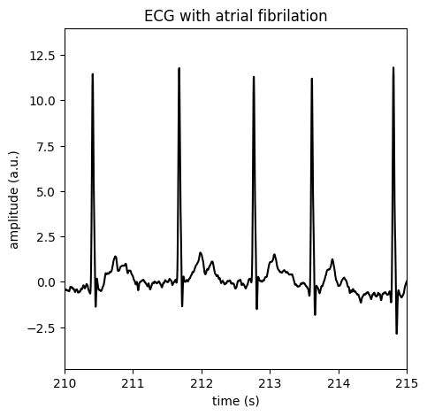

```python
py.figure(1,figsize=[5,5])
py.plot(t_ecg, ecg, 'k')
py.xlabel('time (s)')
py.ylabel('amplitude (a.u.)')
py.title('ECG with atrial fibrilation')
py.xlim(210, 215)
```

We compute the autocorelation of the ECG signal.  
In order to dircard the modulation of the baseline we first apply a  
high-pass filter with a cut-off frequency of 0.5 Hz.  
Q: Do you see a specific pattern that permits to characterize the atrial  
fibrilation?

In the autocorrelation plot shown, the key feature is the lack of clear periodic peaks apart from the central one at k=0.

-For a normal ECG, autocorrelation usually shows secondary peaks at lags corresponding to the heartbeat period (the RR interval). That’s because sinus rhythm is fairly regular: the signal correlates well with itself at multiples of the heart cycle.  
Here, instead, the plot is dominated by a sharp spike at k=0, but the rest looks noisy and irregular, with no strong repetitive structure. This reflects the irregularity nature of atrial fibrillation: the RR intervals vary unpredictably, so the signal doesn’t repeat with a consistent period.

-The pattern that characterizes atrial fibrillation in the autocorrelation is precisely the absence of periodicity: no consistent peaks at regular lags, just a messy background with small, uneven oscillations.

-Basically autocorrelation confirms what the time-domain ECG showed: AF breaks the rhythm, and that broken rhythm leaves its fingerprint as a loss of structure in the autocorrelation.

```python
b, a = sp.butter(2, 0.5/ecg_fs*2, btype='high')
```

```python
ecg_hp = sp.filtfilt(b, a, ecg)
```

```python
rxx_ecg = np.correlate(ecg_hp, ecg_hp, mode='full')
k = np.arange(len(rxx_ecg))-len(rxx_ecg)//2
```

```
(-500.0, 500.0)
```

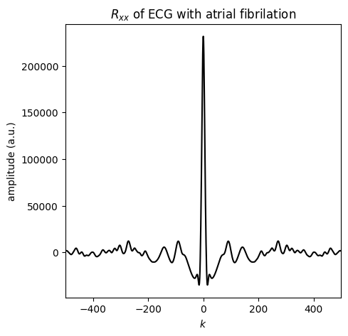

```python
py.figure(2,figsize=[5,5])
py.plot(k, rxx_ecg, 'k')
py.xlabel('$k$')
py.ylabel('amplitude (a.u.)')
py.title('$R_{xx}$ of ECG with atrial fibrilation')
py.xlim(-500, 500)
```

Compute the PSD of the ECG signal.  
Q: What do you see?  
In the power spectral density (PSD) computed, a few things stand out:

- Most of the energy is concentrated below ~20 Hz. That’s typical for ECG, since the main components (P waves, QRS complex, T waves) live in the low-frequency band.

- Broadband spectrum rather than sharp peaks. A normal sinus rhythm often produces clearer, narrowband peaks related to the heart rate and its harmonics (for example around 1–2 Hz, corresponding to ~60–120 bpm).  
In atrial fibrillation, the rhythm is irregular, so instead of well-defined peaks you see a smeared, more continuous spectrum.

- Noticeable power in the low-frequency range (~4–10 Hz). That corresponds to the chaotic atrial activity (the fibrillatory waves), which spreads energy across a wider band instead of being locked to one frequency.

- In the end, what characterizes atrial fibrillation here is exactly the loss of spectral sharpness: the PSD doesn’t highlight a stable, periodic heartbeat frequency, but rather shows a diffuse distribution of power across a range of low frequencies.

```python
f, ECG = sp.welch(ecg_hp, nperseg=500, nfft=4096, noverlap=250, fs=ecg_fs)
```

```
(0.0, 60.0)
```

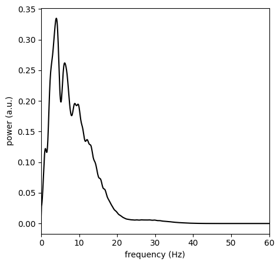

```python
py.figure(3, figsize=[5,5])
py.clf()
py.plot(f, ECG, 'k')
py.xlabel('frequency (Hz)')
py.ylabel('power (a.u.)')
py.xlim(0,60)
```

In order to higlight the signal related to the repolarisation of the  
atria and ECG signal with atrial fibrilation has been process, keeping only  
the P wave (depolarisation of the atria) and the QRST waves have been  
removed.  
During the measurement 4 time segments exhibit different behaviors.  
Q: What are the difference between the different segments ?

- Segment 1 (30–40 s) The atrial activity looks fairly organized: oscillations have high amplitude and a rather consistent rhythm. This is an example of fibrillation with a relatively stable pattern, where the so-called “repolarization loops” are clearly visible.

- Segment 3 (50–60 s) A more ordered pattern reappears, with visible waves and a fairly stable frequency. Atrial activity regains a minimum of coherence, even though it never resembles true sinus rhythm.

- Segment 4 (60–70 s) This is the most chaotic part: lower amplitude, irregular oscillations, and a fragmented trend overall. Here atrial fibrillation shows its most disorganized form, with an almost complete loss of periodicity.

```python
p_wave = np.genfromtxt('AF_sync.dat')
p_wave_fs = 50
t_p_wave = np.arange(len(p_wave))/p_wave_fs
```

```python
segments = [1500, 2000, 2500, 3000, 3500]
```

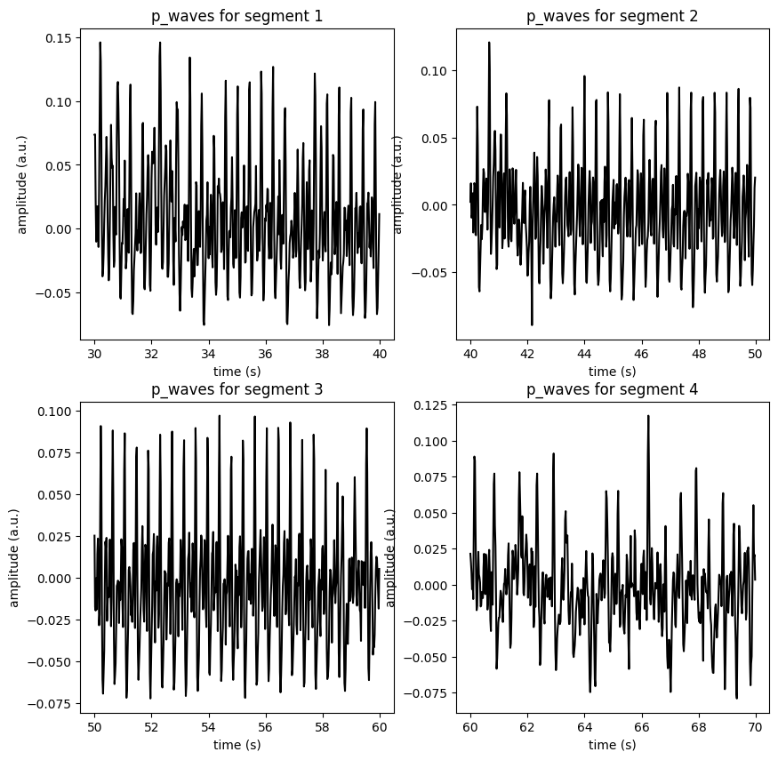

```python
py.figure(4,figsize=[10,10])
for n in range(len(segments)-1):
    py.subplot(2, 2, int(n+1))
    idx = np.arange(segments[n], segments[n+1])
    py.plot(t_p_wave[idx], p_wave[idx], 'k')
    py.xlabel('time (s)')
    py.ylabel('amplitude (a.u.)')
    py.title('p_waves for segment '+str(n+1))
```

We compute the autocorelation of the p_wave signal.  
In order to dircard the modulation of the baseline we first apply a  
high-pass filter with a cut-off frequency of 0.5 Hz.  
Q: Do you see a specific pattern that permits to characterize the atrial  
fibrilation?

Q: Discuss the organisation of the signals. Which one is the more organised,  
which one is closer to a noise?

**Segment 2**: presents some degree of symmetry and structured peaks around zero lag, indicating slightly more organization compared to Segment 1, though still irregular.

**Segment 3**: exhibits the most visible envelope structure in the autocorrelation (a smoother decay and quasi-symmetric shape), suggesting that this segment retains some degree of rhythmic organization despite fibrillation.

**Segment 4**: has very small values with fast decay, appearing almost flat apart from the central peak this indicates minimal organization and behavior closest to pure white noise.

**In summary**: Segment 3 is the most organized (showing some residual structure), while Segment 4 is the closest to noise, with Segments 1 and 2 lying in between.

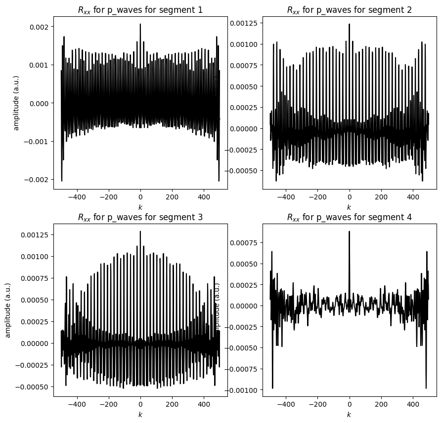

```python
py.figure(5,figsize=[10,10])
for n in range(len(segments)-1):
    py.subplot(2, 2, int(n+1))
    idx = np.arange(segments[n], segments[n+1])
    rxx_p_wave = np.correlate(p_wave[idx], p_wave[idx], mode='full')
    rxx_p_wave /= np.correlate(np.ones(len(idx)), np.ones(len(idx)), mode='full')
    k = np.arange(len(rxx_p_wave))-len(rxx_p_wave)//2
    py.plot(k, rxx_p_wave, 'k')
    py.xlabel('$k$')
    py.ylabel('amplitude (a.u.)')
    py.title('$R_{xx}$ for p_waves for segment '+str(n+1))
```

Compute the PSD of the p_wave signal.  
Q: What do you see?

Q: Which one is the more organised?

Segment 3 is the most organized segment, showing clearly organized peaks in the PSD with the highest ones at 5 and 7 Hz

Q: Which ones looks like a noise?

Q: Which ones exhibit a sustained repolarisation loop?

Segment 3 shows a sustained repolarization loop as it is the most organized signal with high power and well defined frequency components.

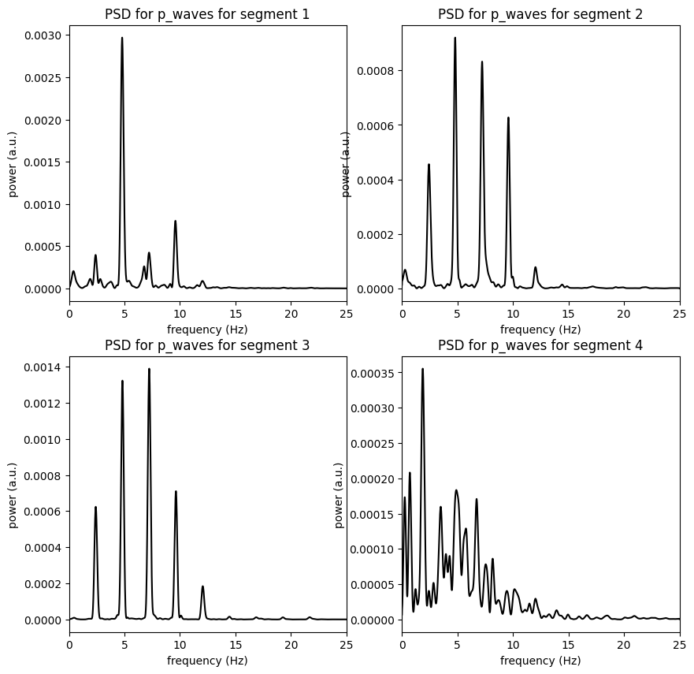

```python
py.figure(7, figsize=[10,10])
for n in range(len(segments)-1):
    idx = np.arange(segments[n], segments[n+1])
    f, P_WAVE = sp.welch(p_wave[idx], nperseg=250, nfft=4096, noverlap=100, fs=p_wave_fs)
    py.subplot(2, 2, int(n+1))
    py.plot(f, P_WAVE, 'k')
    py.xlabel('frequency (Hz)')
    py.ylabel('power (a.u.)')
    py.xlim(0,25)
    py.title('PSD for p_waves for segment '+str(n+1))
```